# Part II - Students Skill/Performance Analysis

## by Jessica Chizoba Nkwa

## Investigation Overview

> In this pisa dataset investigation, I looked at the effect of parental background (such degree, income, and occupation status) and student interest toward student academic performance. The main focus was on how many features contribute to student performance in their academics.

## Dataset Overview

> PISA is a survey of students' skills and knowledge as they approach the end of compulsory education. It is not a conventional school test. Rather than examining how well students have learned the school curriculum, it looks at how well prepared they are for life beyond school.

## (Visualization 1)

> The most common country with the highest number of students that participated in the survey

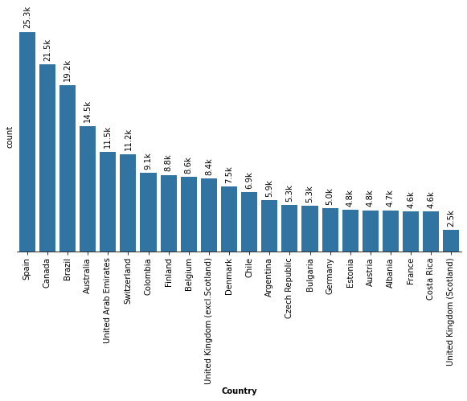

From the chart, it shows that Spain, Canada and Brazil are the three top countries that filled out the survey

## (Visualization 2)

> Academic performance on primary education and its effect

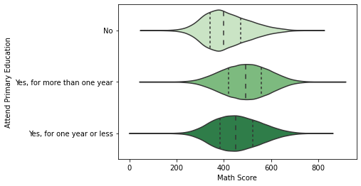

There is a significant increase in the scores of student's based on their experience in primary education and its predominant in Mathematics performance.

## (Visualization 3)

> Relationship between all numeric data

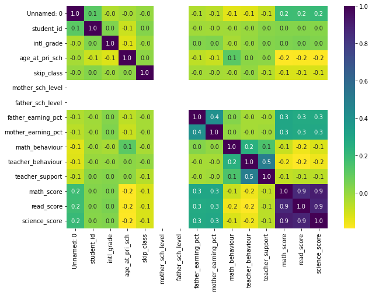

## (Visualization 4)

> Effect of students performance based on parental employment status

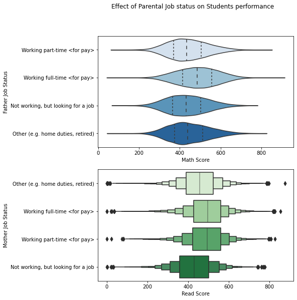

Students with parents working full-time tend to perform better than students whose parents are looking for job. It is convenient to conclude that parent occupation is related to student performance.

[output not shown]